# Week 7 modules

## Type II Error

```r
typeII <- function(mu0, muA, sigma, n, alternative = "two.tailed", alpha = 0.05,
    k = 1000) {
    p <- rep(NA, k)  # sets up a vector of empty p values
    for (i in 1:k) {
        x <- rnorm(n = n, mean = muA, sd = sigma)  # draw from Ha
        m <- mean(x)
        s <- sd(x)
        z <- (m - mu0)/(s/sqrt(n))  # calculates the Z statistic for the sample drawn from Ha relative to the null distribution
        if (alternative == "less") {
            p[i] <- pnorm(z, lower.tail = TRUE)  # calculates the associated p value
            hyp <- "muA < mu0"
        }
        if (alternative == "greater") {
            p[i] <- pnorm(z, lower.tail = FALSE)
            hyp <- "muA > mu0"
        }
        if (alternative == "two.tailed") {
            if (z > 0) {
                p[i] <- 2 * pnorm(z, lower.tail = FALSE)
            }
            if (z < 0) {
                p[i] <- 2 * pnorm(z, lower.tail = TRUE)
            }
            hyp <- "muA ≠ mu0"
        }
    }

    curve(dnorm(x, mu0, sigma/sqrt(n)), mu0 - 4 * sigma/sqrt(n), mu0 + 4 * sigma/sqrt(n),
        main = paste("Sampling Distributions Under the Null (red)\nand Alternative Hypotheses (blue)\nType II error rate from simulation = ",
            length(p[p >= alpha])/k, sep = ""), xlab = "x", ylab = "Pr(x)",
        col = "red", xlim = c(min(c(mu0 - 4 * sigma/sqrt(n), muA - 4 * sigma/sqrt(n))),
            max(c(mu0 + 4 * sigma/sqrt(n), muA + 4 * sigma/sqrt(n)))), ylim = c(0,
            max(c(dnorm(mu0, mu0, sigma/sqrt(n))), dnorm(muA, muA, sigma/sqrt(n)))))

    curve(dnorm(x, muA, sigma/sqrt(n)), muA - 4 * sigma/sqrt(n), muA + 4 * sigma/sqrt(n),
        col = "blue", add = TRUE)
    abline(h = 0)

    if (alternative == "less") {
        polygon(cbind(c(mu0 - qnorm(1 - alpha) * sigma/sqrt(n), seq(from = mu0 -
            qnorm(1 - alpha) * sigma/sqrt(n), to = muA + 4 * sigma/sqrt(n),
            length.out = 100), muA + 4 * sigma/sqrt(n))), c(0, dnorm(seq(mu0 -
            qnorm(1 - alpha) * sigma/sqrt(n), to = muA + 4 * sigma/sqrt(n),
            length.out = 100), mean = muA, sd = sigma/sqrt(n)), 0), border = "black",
            col = "grey")
        abline(v = mu0 - qnorm(1 - alpha) * sigma/sqrt(n), col = "black", lty = 3,
            lwd = 2)
    }

    if (alternative == "greater") {
        polygon(cbind(c(muA - 4 * sigma/sqrt(n), seq(from = muA - 4 * sigma/sqrt(n),
            to = mu0 + qnorm(1 - alpha) * sigma/sqrt(n), length.out = 100),
            mu0 + qnorm(1 - alpha) * sigma/sqrt(n))), c(0, dnorm(seq(from = muA -
            4 * sigma/sqrt(n), to = mu0 + qnorm(1 - alpha) * sigma/sqrt(n),
            length.out = 100), mean = muA, sd = sigma/sqrt(n)), 0), border = "black",
            col = "grey")
        abline(v = mu0 + qnorm(1 - alpha) * sigma/sqrt(n), col = "black", lty = 3,
            lwd = 2)
    }

    if (alternative == "two.tailed") {
        abline(v = mu0 - qnorm(1 - alpha/2) * sigma/sqrt(n), col = "black",
            lty = 3, lwd = 2)
        abline(v = mu0 + qnorm(1 - alpha/2) * sigma/sqrt(n), col = "black",
            lty = 3, lwd = 2)

        if (z > 0) {
            # greater
            polygon(cbind(c(muA - 4 * sigma/sqrt(n), seq(from = muA - 4 * sigma/sqrt(n),
                to = mu0 + qnorm(1 - alpha/2) * sigma/sqrt(n), length.out = 100),
                mu0 + qnorm(1 - alpha/2) * sigma/sqrt(n))), c(0, dnorm(seq(from = muA -
                4 * sigma/sqrt(n), to = mu0 + qnorm(1 - alpha/2) * sigma/sqrt(n),
                length.out = 100), mean = muA, sd = sigma/sqrt(n)), 0), border = "black",
                col = "grey")
        }

        # less
        if (z < 0) {
            polygon(cbind(c(mu0 - qnorm(1 - alpha/2) * sigma/sqrt(n), seq(from = mu0 -
                qnorm(1 - alpha/2) * sigma/sqrt(n), to = muA + 4 * sigma/sqrt(n),
                length.out = 100), muA + 4 * sigma/sqrt(n))), c(0, dnorm(seq(mu0 -
                qnorm(1 - alpha/2) * sigma/sqrt(n), to = muA + 4 * sigma/sqrt(n),
                length.out = 100), mean = muA, sd = sigma/sqrt(n)), 0), border = "black",
                col = "grey")
        }
    }

    return(length(p[p >= alpha])/k)
}
```

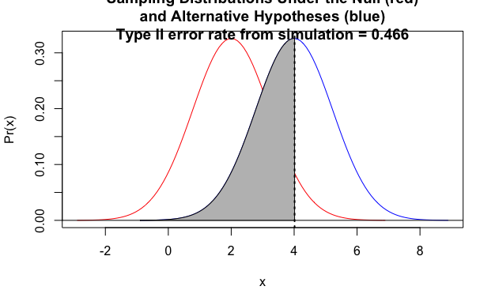

```r
eII <- typeII(mu0 = 2, muA = 4, sigma = 3, n = 6, alternative = "greater")  # Ha > H0
```

Questions: is n (Type II error function), refering to number in each sample, or all together

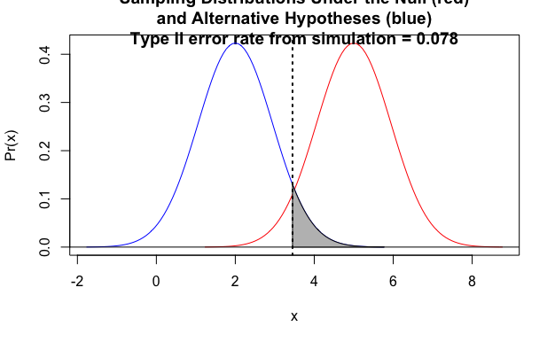

```r
eII <- typeII(mu0 = 5, muA = 2, sigma = 4, n = 18, alternative = "less")  # Ha < H0
```

## Effect Size

### Graphical Depiction of Power and Effect Size

```r
library(ggplot2)
library(manipulate)
power.plot <- function(sigma, muA, mu0, n, alpha, alternative = "two.tailed") {
    pow <- 0
    z <- (muA - mu0)/(sigma/sqrt(n))
    g <- ggplot(data.frame(mu = c(min(mu0 - 4 * sigma/sqrt(n), muA - 4 * sigma/sqrt(n)),
        max(mu0 + 4 * sigma/sqrt(n), muA + 4 * sigma/sqrt(n)))), aes(x = mu)) +
        ggtitle("Explore Power for Z Test")
    g <- g + ylim(c(0, max(dnorm(mu0, mu0, sigma/sqrt(n)) + 0.1, dnorm(muA,
        muA, sigma/sqrt(n)) + 0.1)))
    g <- g + stat_function(fun = dnorm, geom = "line", args = list(mean = mu0,
        sd = sigma/sqrt(n)), size = 1, col = "red", show.legend = TRUE)
    g <- g + stat_function(fun = dnorm, geom = "line", args = list(mean = muA,
        sd = sigma/sqrt(n)), size = 1, col = "blue", show.legend = TRUE)

    if (alternative == "greater") {
        if (z > 0) {
            xcrit = mu0 + qnorm(1 - alpha) * sigma/sqrt(n)
            g <- g + geom_segment(x = xcrit, y = 0, xend = xcrit, yend = max(dnorm(mu0,
                mu0, sigma/sqrt(n)) + 0.025, dnorm(muA, muA, sigma/sqrt(n)) +
                0.025), size = 0.5, linetype = 3)
            g <- g + geom_polygon(data = data.frame(cbind(x = c(xcrit, seq(from = xcrit,
                to = muA + 4 * sigma/sqrt(n), length.out = 100), muA + 4 * sigma/sqrt(n)),
                y = c(0, dnorm(seq(from = xcrit, to = muA + 4 * sigma/sqrt(n),
                  length.out = 100), mean = muA, sd = sigma/sqrt(n)), 0))),
                aes(x = x, y = y), fill = "blue", alpha = 0.5)
            pow <- pnorm(muA + 4 * sigma/sqrt(n), muA, sigma/sqrt(n)) - pnorm(xcrit,
                muA, sigma/sqrt(n))
        }
    }
    if (alternative == "less") {
        if (z < 0) {
            xcrit = mu0 - qnorm(1 - alpha) * sigma/sqrt(n)
            g <- g + geom_segment(x = xcrit, y = 0, xend = xcrit, yend = max(dnorm(mu0,
                mu0, sigma/sqrt(n)) + 0.025, dnorm(muA, muA, sigma/sqrt(n)) +
                0.025), size = 0.5, linetype = 3)
            g <- g + geom_polygon(data = data.frame(cbind(x = c(muA - 4 * sigma/sqrt(n),
                seq(from = muA - 4 * sigma/sqrt(n), to = xcrit, length.out = 100),
                xcrit), y = c(0, dnorm(seq(from = muA - 4 * sigma/sqrt(n), to = xcrit,
                length.out = 100), mean = muA, sd = sigma/sqrt(n)), 0))), aes(x = x,
                y = y), fill = "blue", alpha = 0.5)
            pow <- pnorm(xcrit, muA, sigma/sqrt(n)) - pnorm(muA - 4 * sigma/sqrt(n),
                muA, sigma/sqrt(n))
        }
    }
    if (alternative == "two.tailed") {
        if (z > 0) {
            xcrit = mu0 + qnorm(1 - alpha/2) * sigma/sqrt(n)
            g <- g + geom_segment(x = xcrit, y = 0, xend = xcrit, yend = max(dnorm(mu0,
                mu0, sigma/sqrt(n)) + 0.025, dnorm(muA, muA, sigma/sqrt(n)) +
                0.025), size = 0.5, linetype = 3)
            g <- g + geom_polygon(data = data.frame(cbind(x = c(xcrit, seq(from = xcrit,
                to = muA + 4 * sigma/sqrt(n), length.out = 100), muA + 4 * sigma/sqrt(n)),
                y = c(0, dnorm(seq(from = xcrit, to = muA + 4 * sigma/sqrt(n),
                  length.out = 100), mean = muA, sd = sigma/sqrt(n)), 0))),
                aes(x = x, y = y), fill = "blue", alpha = 0.5)
            pow <- pnorm(muA + 4 * sigma/sqrt(n), muA, sigma/sqrt(n)) - pnorm(xcrit,
                muA, sigma/sqrt(n))
        }
        if (z < 0) {
            xcrit = mu0 - qnorm(1 - alpha/2) * sigma/sqrt(n)
            g <- g + geom_segment(x = xcrit, y = 0, xend = xcrit, yend = max(dnorm(mu0,
                mu0, sigma/sqrt(n)) + 0.025, dnorm(muA, muA, sigma/sqrt(n)) +
                0.025), size = 0.5, linetype = 3)
            g <- g + geom_polygon(data = data.frame(cbind(x = c(muA - 4 * sigma/sqrt(n),
                seq(from = muA - 4 * sigma/sqrt(n), to = xcrit, length.out = 100),
                xcrit), y = c(0, dnorm(seq(from = muA - 4 * sigma/sqrt(n), to = xcrit,
                length.out = 100), mean = muA, sd = sigma/sqrt(n)), 0))), aes(x = x,
                y = y), fill = "blue", alpha = 0.5)
            pow <- pnorm(xcrit, muA, sigma/sqrt(n)) - pnorm(muA - 4 * sigma/sqrt(n),
                muA, sigma/sqrt(n))
        }
    }
    g <- g + annotate("text", x = max(mu0, muA) + 2 * sigma/sqrt(n), y = max(dnorm(mu0,
        mu0, sigma/sqrt(n)) + 0.075, dnorm(muA, muA, sigma/sqrt(n)) + 0.075),
        label = paste("Effect Size = ", round((muA - mu0)/sigma, digits = 3),
            "\nPower = ", round(pow, digits = 3), sep = ""))
    g <- g + annotate("text", x = min(mu0, muA) - 2 * sigma/sqrt(n), y = max(dnorm(mu0,
        mu0, sigma/sqrt(n)) + 0.075, dnorm(muA, muA, sigma/sqrt(n)) + 0.075),
        label = "Red = mu0\nBlue = muA")
    g
}
```

```r
manipulate(power.plot(sigma, muA, mu0, n, alpha, alternative), sigma = slider(1,
    10, step = 1, initial = 4), muA = slider(-10, 10, step = 1, initial = 2),
    mu0 = slider(-10, 10, step = 1, initial = 0), n = slider(1, 50, step = 1,
        initial = 16), alpha = slider(0.01, 0.1, step = 0.01, initial = 0.05),
    alternative = picker("two.tailed", "greater", "less"))
#use bootstrapping to help find the power.
```

```r
library(ggplot2)
library(manipulate)
power.test <- function(mu0, muA, sigma, alpha = 0.05, type, alternative) {
    p <- 0
    for (i in 2:200) {
        x <- power.t.test(n = i, delta = abs(muA - mu0), sd = sigma, sig.level = alpha,
            power = NULL, type = type, alternative = alternative)
        p <- c(p, x$power)
    }
    d <- data.frame(cbind(1:200, p, 1 - p))
    critn <- 0
    for (i in 1:199) {
        if (p[i] < 0.8 && p[i + 1] >= 0.8) {
            critn <- i + 1
        } else {
            critn <- critn
        }
    }
    names(d) <- c("n", "power", "beta")
    g <- ggplot(data = d) + xlab("sample size n") + ylab("Type II Error Rate, Beta  (Red)\nand\nPower, 1-Beta (Blue)") +
        ggtitle("Power for T Tests\n(assuming equal n and variance across the two groups)") +
        ylim(0, 1) + geom_point(aes(x = n, y = power), colour = "blue", alpha = 1/2) +
        geom_line(aes(x = n, y = power), colour = "blue", alpha = 1/2) + geom_line(aes(x = n,
        y = 0.8), colour = "red", lty = 3) + geom_point(aes(x = n, y = beta),
        colour = "red", alpha = 1/2) + geom_line(aes(x = n, y = beta), colour = "red",
        alpha = 1/2) + geom_linerange(aes(x = critn, ymin = 0, ymax = 0.8),
        colour = "blue", alpha = 1/4) + annotate("text", x = 150, y = 0.5, label = paste("Effect Size = ",
        round(abs(mu0 - muA)/sigma, digits = 3), "\nCritical n = ", critn, sep = ""))
    print(g)
}
```

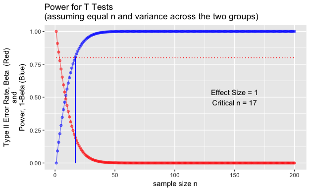

```r
manipulate(power.test(mu0, muA, sigma, alpha, type, alternative), mu0 = slider(-10,
    10, initial = 3, step = 1), muA = slider(-10, 10, initial = 0, step = 1),
    sigma = slider(1, 10, initial = 3, step = 1), alpha = slider(0.01, 0.1,
        initial = 0.05, step = 0.01), alternative = picker("two.sided", "one.sided"),
    type = picker("two.sample", "one.sample", "paired"))
```

# Module 12 – Only use model 1 (OLS) if you are really secure on the measurement of x

install.packages(“lmodel2”) install.packages(“gridExtra”)

## Introduction to Linear Regression

## Covariance and Correlation

```r
library(curl)
library(ggplot2)
f <- curl("https://raw.githubusercontent.com/fuzzyatelin/fuzzyatelin.github.io/master/AN597_Fall17/zombies.csv")
d <- read.csv(f, header = TRUE, sep = ",", stringsAsFactors = FALSE)
head(d)
```

|  | id | first_name | last_name | gender | height | weight | zombies_killed | years_of_education | major | age |
| --- | --- | --- | --- | --- | --- | --- | --- | --- | --- | --- |
| 1 | 1 | Sarah | Little | Female | 62.88951 | 132.0872 | 2 | 1 | medicine/nursing | 17.64275 |
| 2 | 2 | Mark | Duncan | Male | 67.80277 | 146.3753 | 5 | 3 | criminal justice administration | 22.58951 |
| 3 | 3 | Brandon | Perez | Male | 72.12908 | 152.9370 | 1 | 1 | education | 21.91276 |
| 4 | 4 | Roger | Coleman | Male | 66.78484 | 129.7418 | 5 | 6 | energy studies | 18.19058 |
| 5 | 5 | Tammy | Powell | Female | 64.71832 | 132.4265 | 4 | 3 | logistics | 21.10399 |
| 6 | 6 | Anthony | Green | Male | 71.24326 | 152.5246 | 1 | 4 | energy studies | 21.48355 |

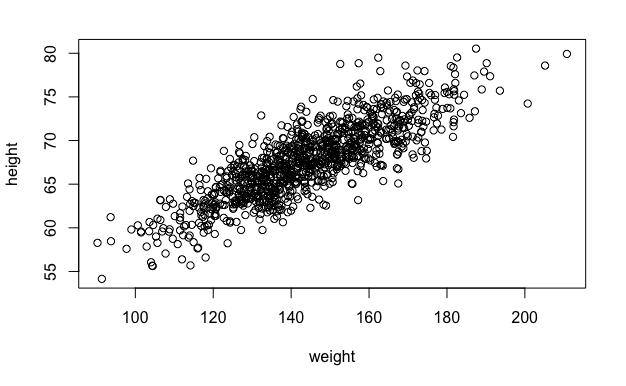

```r
plot(data = d, height ~ weight)
```

CHALLENGE:

What is the covariance between zombie weight and zombie height? What does it mean if the covariance is positive versus negative? Does it matter if you switch the order of the two variables?

```r
w <- d$weight
h <- d$height
n <- length(w)  # or length(h)
cov_wh <- sum((w - mean(w)) * (h - mean(h)))/(n - 1)
cov_wh
```

```
[1] 66.03314
```

```r
cov(w, h)
```

```
[1] 66.03314
```

CHALLENGE:

Calculate the correlation between zombie height and weight.

```r
sd_w <- sd(w)
sd_h <- sd(h)
cor_wh <- cov_wh/(sd_w * sd_h)
cor_wh
```

```
[1] 0.8325862
```

```r
cor(w, h)
```

```
[1] 0.8325862
```

This formulation of the correlation coefficient is referred to as Pearson’s product-moment correlation coefficient and is often abbreviated as ρρ.

There are other, nonparametric forms of the correlation coefficient we might also calculate

```r
cor(w, h, method = "kendall")
```

```
[1] 0.6331932
```

```r
cor(w, h, method = "spearman")
```

[output not shown]

## Regression

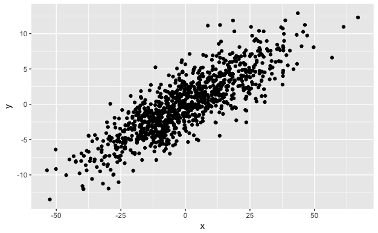

```r
y <- h - mean(h)
x <- w - mean(w)
z <- data.frame(cbind(x, y))
g <- ggplot(data = z, aes(x = x, y = y)) + geom_point()
g
```

```r
slope.test <- function(beta1) {
    g <- ggplot(data = z, aes(x = x, y = y))
    g <- g + geom_point()
    g <- g + geom_abline(intercept = 0, slope = beta1, size = 1, colour = "blue",
        alpha = 1/2)
    ols <- sum((y - beta1 * x)^2)
    g <- g + ggtitle(paste("Slope = ", beta1, "\nSum of Squared Deviations = ",
        round(ols, 3)))
    g
}
```

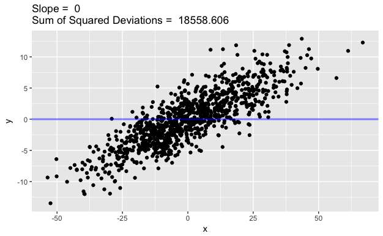

```r
manipulate(slope.test(beta1), beta1 = slider(-1, 1, initial = 0, step = 0.005))
```

```r
beta1 <- cor(w, h) * (sd(h)/sd(w))
beta1
```

```
[1] 0.1950187
```

```r
beta1 <- cov(w, h)/var(w)
beta1
```

```
[1] 0.1950187
```

```r
beta1 <- sum((h - mean(h)) * (w - mean(w)))/sum((w - mean(w))^2)
beta1
```

```
[1] 0.1950187
```

```r
beta0 <- mean(h) - beta1 * mean(w)
beta0
```

```
[1] 39.56545
```

## The lm Function

```r
m <- lm(height ~ weight, data = d)
m
```

```
Call:
lm(formula = height ~ weight, data = d)

Coefficients:
(Intercept)       weight
     39.565        0.195
```

```r
names(m)
```

```
 [1] "coefficients"  "residuals"     "effects"       "rank"
 [5] "fitted.values" "assign"        "qr"            "df.residual"
 [9] "xlevels"       "call"          "terms"         "model"
```

```r
m$coefficients
```

```
(Intercept)      weight
 39.5654460   0.1950187
```

```r
head(m$model)
```

|  | height | weight |
| --- | --- | --- |
| 1 | 62.88951 | 132.0872 |
| 2 | 67.80277 | 146.3753 |
| 3 | 72.12908 | 152.9370 |
| 4 | 66.78484 | 129.7418 |
| 5 | 64.71832 | 132.4265 |
| 6 | 71.24326 | 152.5246 |

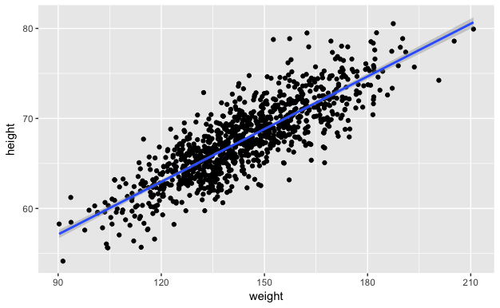

```r
g <- ggplot(data = d, aes(x = weight, y = height))
g <- g + geom_point()
g <- g + geom_smooth(method = "lm", formula = y ~ x)
g
```

```r
library(lmodel2)  # load the lmodel2 package
# Run the regression
mII <- lmodel2(height ~ weight, data = d, range.y = "relative", range.x = "relative",
    nperm = 1000)
mII
```

```
Model II regression

Call: lmodel2(formula = height ~ weight, data = d, range.y =
"relative", range.x = "relative", nperm = 1000)

n = 1000   r = 0.8325862   r-square = 0.6931998
Parametric P-values:   2-tailed = 2.646279e-258    1-tailed = 1.32314e-258
Angle between the two OLS regression lines = 4.677707 degrees

Permutation tests of OLS, MA, RMA slopes: 1-tailed, tail corresponding to sign
A permutation test of r is equivalent to a permutation test of the OLS slope
P-perm for SMA = NA because the SMA slope cannot be tested

Regression results
  Method Intercept     Slope Angle (degrees) P-perm (1-tailed)
1    OLS  39.56545 0.1950187        11.03524       0.000999001
2     MA  39.10314 0.1982313        11.21246       0.000999001
3    SMA  33.92229 0.2342325        13.18287                NA
4    RMA  36.80125 0.2142269        12.09153       0.000999001

Confidence intervals
  Method 2.5%-Intercept 97.5%-Intercept 2.5%-Slope 97.5%-Slope
1    OLS       38.39625        40.73464  0.1869597   0.2030778
2     MA       37.92239        40.28020  0.1900520   0.2064362
3    SMA       32.74259        35.06211  0.2263120   0.2424301
4    RMA       35.51434        38.06296  0.2054593   0.2231695

Eigenvalues: 351.6888 5.48735

H statistic used for computing C.I. of MA: 6.212738e-05
```

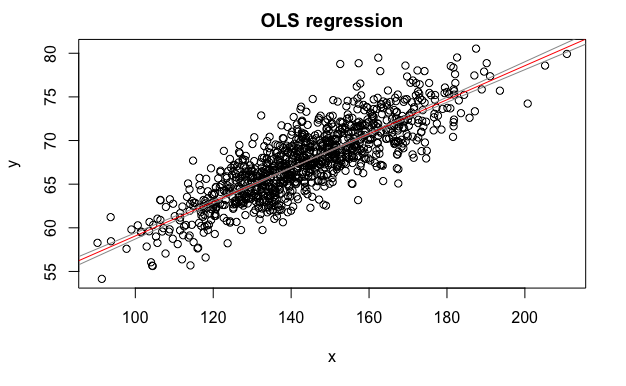

```r
plot(mII, "OLS")
```

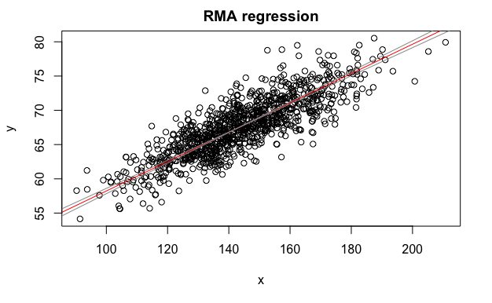

```r
plot(mII, "RMA")
```

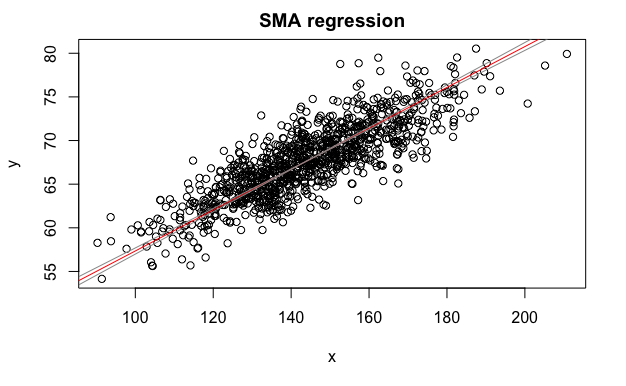

```r
plot(mII, "SMA")
```

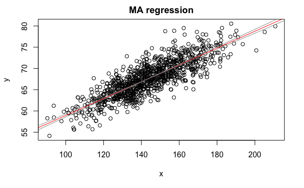

```r
plot(mII, "MA")
```

```r
mI <- lm(height ~ weight, data = d)
summary(mI)
```

```
Call:
lm(formula = height ~ weight, data = d)

Residuals:
    Min      1Q  Median      3Q     Max
-7.1519 -1.5206 -0.0535  1.5167  9.4439

Coefficients:
             Estimate Std. Error t value Pr(>|t|)
(Intercept) 39.565446   0.595815   66.41   <2e-16 ***
weight       0.195019   0.004107   47.49   <2e-16 ***
---
Signif. codes:  0 ‘***’ 0.001 ‘**’ 0.01 ‘*’ 0.05 ‘.’ 0.1 ‘ ’ 1

Residual standard error: 2.389 on 998 degrees of freedom
Multiple R-squared:  0.6932,    Adjusted R-squared:  0.6929
F-statistic:  2255 on 1 and 998 DF,  p-value: < 2.2e-16
```

```r
par(mfrow = c(1, 2))
plot(mII, main = "lmodel2() OLS")
plot(data = d, height ~ weight, main = "lm()")
```

[figure not shown]

```r
abline(mI)
```

CHALLENGE:

Using the zombies dataset, work with a partner to…

Plot zombie height as a function of age Derive by hand the ordinary least squares regression coefficients β1 and β0 for these data. Confirm that you get the same results using the lm() function Repeat the analysis above for males and females separately. Do your regression coefficients differ? How might you determine this?

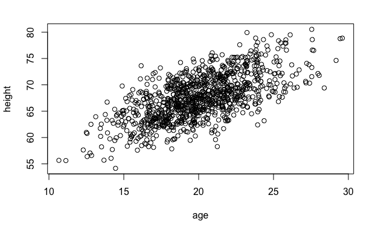

```r
plot(data = d, height ~ age)
```

```r
beta1 <- cor(d$height, d$age) * sd(d$height)/sd(d$age)
beta1
```

```
[1] 0.9425086
```

```r
beta0 <- mean(d$height) - beta1 * mean(d$age)
beta0
```

```
[1] 48.73566
```

```r
m <- lm(height ~ age, data = d)
m
```

```
Call:
lm(formula = height ~ age, data = d)

Coefficients:
(Intercept)          age
    48.7357       0.9425
```

## Statistical Inference in Regression

```r
m <- lm(data = d, height ~ weight)
summary(m)
```

```
Call:
lm(formula = height ~ weight, data = d)

Residuals:
    Min      1Q  Median      3Q     Max
-7.1519 -1.5206 -0.0535  1.5167  9.4439

Coefficients:
             Estimate Std. Error t value Pr(>|t|)
(Intercept) 39.565446   0.595815   66.41   <2e-16 ***
weight       0.195019   0.004107   47.49   <2e-16 ***
---
Signif. codes:  0 ‘***’ 0.001 ‘**’ 0.01 ‘*’ 0.05 ‘.’ 0.1 ‘ ’ 1

Residual standard error: 2.389 on 998 degrees of freedom
Multiple R-squared:  0.6932,    Adjusted R-squared:  0.6929
F-statistic:  2255 on 1 and 998 DF,  p-value: < 2.2e-16
```

In our regression, ~69% of the variation in zombie height is explained by zombie weight.

```r
t <- coef(summary(m))
t <- data.frame(unlist(t))
colnames(t) <- c("Est", "SE", "t", "p")
t
```

|  | Est | SE | t | p |
| --- | --- | --- | --- | --- |
| (Intercept) | 39.5654460 | 0.595814678 | 66.40562 | 0.000000e+00 |
| weight | 0.1950187 | 0.004106858 | 47.48611 | 2.646279e-258 |

```r
t$calct <- (t$Est - 0)/t$SE
t$calcp <- 2 * pt(t$calct, df = 998, lower.tail = FALSE)  # x2 because is 2-tailed test
t
```

|  | Est | SE | t | p | calct | calcp |
| --- | --- | --- | --- | --- | --- | --- |
| (Intercept) | 39.5654460 | 0.595814678 | 66.40562 | 0.000000e+00 | 66.40562 | 0.000000e+00 |
| weight | 0.1950187 | 0.004106858 | 47.48611 | 2.646279e-258 | 47.48611 | 2.646279e-258 |

```r
ci <- confint(m, level = 0.95)  # using the results of lm()
ci
```

```
                 2.5 %     97.5 %
(Intercept) 38.3962527 40.7346393
weight       0.1869597  0.2030778
```

## Interpreting Regression Coefficients and Prediction

CHALLENGE:

If zombie weight is measured in pounds and zombie height is measured in inches, what is the expected height of a zombie weighing 150 pounds? What is the predicted difference in height between a zombie weighing 180 and 220 pounds?

```r
beta0 <- t$Est[1]
beta1 <- t$Est[2]
h_hat <- beta1 * 150 + beta0
h_hat
```

```
[1] 68.81825
```

```r
h_hat_difference <- (beta1 * 220 + beta0) - (beta1 * 180 + beta0)
h_hat_difference
```

```
[1] 7.800749
```

```r
m <- lm(data = d, height ~ weight)
h_hat <- predict(m, newdata = data.frame(weight = d$weight))
df <- data.frame(cbind(d$weight, d$height, h_hat))
names(df) <- c("x", "y", "yhat")
head(df)
```

|  | x | y | yhat |
| --- | --- | --- | --- |
| 1 | 132.0872 | 62.88951 | 65.32492 |
| 2 | 146.3753 | 67.80277 | 68.11137 |
| 3 | 152.9370 | 72.12908 | 69.39103 |
| 4 | 129.7418 | 66.78484 | 64.86753 |
| 5 | 132.4265 | 64.71832 | 65.39109 |
| 6 | 152.5246 | 71.24326 | 69.31059 |

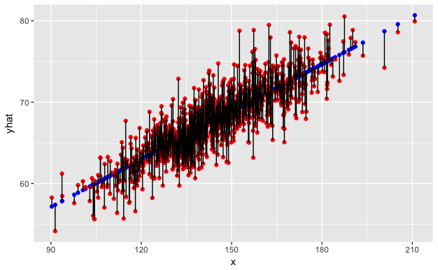

```r
g <- ggplot(data = df, aes(x = x, y = yhat))
g <- g + geom_point(color="blue")
g <- g + geom_point(aes(x = x, y = y), colour = "red")
g <- g + geom_segment(aes(x = x, y = yhat, xend = x, yend = y))
g
```

```r
ci <- predict(m, newdata = data.frame(weight = 150), interval = "confidence",
    level = 0.95)  # for a single value
ci
```

```
       fit      lwr     upr
1 68.81825 68.66211 68.9744
```

```r
ci <- predict(m, newdata = data.frame(weight = d$weight), interval = "confidence",
    level = 0.95)  # for a vector of values
head(ci)
```

```
       fit      lwr      upr
1 65.32492 65.14872 65.50111
2 68.11137 67.96182 68.26092
3 69.39103 69.22591 69.55615
4 64.86753 64.68044 65.05462
5 65.39109 65.21636 65.56582
6 69.31059 69.14691 69.47428
```

```r
df <- cbind(df, ci)
names(df) <- c("x", "y", "yhat", "CIfit", "CIlwr", "CIupr")
head(df)
```

|  | x | y | yhat | CIfit | CIlwr | CIupr |
| --- | --- | --- | --- | --- | --- | --- |
| 1 | 132.0872 | 62.88951 | 65.32492 | 65.32492 | 65.14872 | 65.50111 |
| 2 | 146.3753 | 67.80277 | 68.11137 | 68.11137 | 67.96182 | 68.26092 |
| 3 | 152.9370 | 72.12908 | 69.39103 | 69.39103 | 69.22591 | 69.55615 |
| 4 | 129.7418 | 66.78484 | 64.86753 | 64.86753 | 64.68044 | 65.05462 |
| 5 | 132.4265 | 64.71832 | 65.39109 | 65.39109 | 65.21636 | 65.56582 |
| 6 | 152.5246 | 71.24326 | 69.31059 | 69.31059 | 69.14691 | 69.47428 |

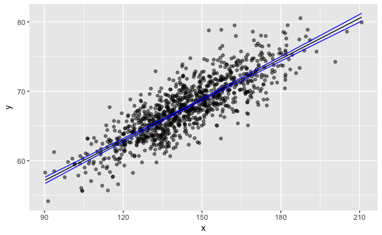

```r
g <- ggplot(data = df, aes(x = x, y = y))
g <- g + geom_point(alpha = 1/2)
g <- g + geom_line(aes(x = x, y = CIfit), colour = "black")
g <- g + geom_line(aes(x = x, y = CIlwr), colour = "blue")
g <- g + geom_line(aes(x = x, y = CIupr), colour = "blue")
g
```

```r
pi <- predict(m, newdata = data.frame(weight = 150), interval = "prediction",
    level = 0.95)  # for a single value
pi
```

```
       fit      lwr      upr
1 68.81825 64.12849 73.50802
```

```r
pi <- predict(m, newdata = data.frame(weight = d$weight), interval = "prediction",
    level = 0.95)  # for a vector of values
head(pi)
```

```
       fit      lwr      upr
1 65.32492 60.63444 70.01539
2 68.11137 63.42182 72.80092
3 69.39103 64.70095 74.08110
4 64.86753 60.17663 69.55843
5 65.39109 60.70067 70.08151
6 69.31059 64.62057 74.00062
```

```r
df <- cbind(df, pi)
names(df) <- c("x", "y", "yhat", "CIfit", "CIlwr", "CIupr", "PIfit", "PIlwr",
    "PIupr")
head(df)
```

|  | x | y | yhat | CIfit | CIlwr | CIupr | PIfit | PIlwr | PIupr |
| --- | --- | --- | --- | --- | --- | --- | --- | --- | --- |
| 1 | 132.0872 | 62.88951 | 65.32492 | 65.32492 | 65.14872 | 65.50111 | 65.32492 | 60.63444 | 70.01539 |
| 2 | 146.3753 | 67.80277 | 68.11137 | 68.11137 | 67.96182 | 68.26092 | 68.11137 | 63.42182 | 72.80092 |
| 3 | 152.9370 | 72.12908 | 69.39103 | 69.39103 | 69.22591 | 69.55615 | 69.39103 | 64.70095 | 74.08110 |
| 4 | 129.7418 | 66.78484 | 64.86753 | 64.86753 | 64.68044 | 65.05462 | 64.86753 | 60.17663 | 69.55843 |
| 5 | 132.4265 | 64.71832 | 65.39109 | 65.39109 | 65.21636 | 65.56582 | 65.39109 | 60.70067 | 70.08151 |
| 6 | 152.5246 | 71.24326 | 69.31059 | 69.31059 | 69.14691 | 69.47428 | 69.31059 | 64.62057 | 74.00062 |

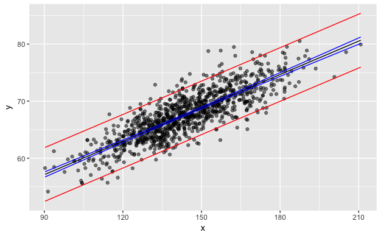

```r
g <- g + geom_line(data = df, aes(x = x, y = PIlwr), colour = "red")
g <- g + geom_line(data = df, aes(x = x, y = PIupr), colour = "red")
g
```

CHALLENGE:

Construct a linear model for the regression of zombie height on age and predict the mean height, the 95% confidence interval (CI) around the predicted mean height, and the 95% prediction interval (PI) around that mean for a vector of zombie ages, v <- seq(from=10, to=30, by=1). Then, plot your points, your regression line, and lines for the lower and upper limits of the CI and of the PI.

```r
v <- seq(from = 10, to = 30, by = 1)
m <- lm(data = d, height ~ age)
ci <- predict(m, newdata = data.frame(age = v), interval = "confidence", level = 0.95)
pi <- predict(m, newdata = data.frame(age = v), interval = "prediction", level = 0.95)
plot(data = d, height ~ age)
lines(x = v, y = ci[, 1], col = "black")
```

```r
lines(x = v, y = ci[, 2], col = "blue")
lines(x = v, y = ci[, 3], col = "blue")
```

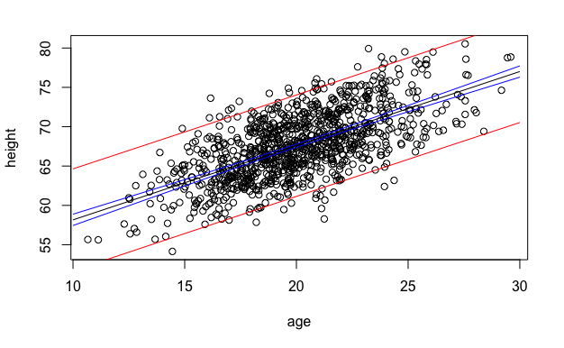

```r
lines(x = v, y = pi[, 2], col = "red")
lines(x = v, y = pi[, 3], col = "red")
```

```r
# or
require(gridExtra)
require(ggplot2)
df <- data.frame(cbind(v, ci, pi))
names(df) <- c("age", "CIfit", "CIlwr", "CIupr", "PIfit", "PIlwr", "PIupr")
head(df)
```

|  | age | CIfit | CIlwr | CIupr | PIfit | PIlwr | PIupr |
| --- | --- | --- | --- | --- | --- | --- | --- |
| 1 | 10 | 58.16075 | 57.44067 | 58.88083 | 58.16075 | 51.67823 | 64.64327 |
| 2 | 11 | 59.10326 | 58.44882 | 59.75770 | 59.10326 | 52.62770 | 65.57882 |
| 3 | 12 | 60.04577 | 59.45627 | 60.63527 | 60.04577 | 53.57645 | 66.51509 |
| 4 | 13 | 60.98828 | 60.46275 | 61.51380 | 60.98828 | 54.52447 | 67.45208 |
| 5 | 14 | 61.93079 | 61.46786 | 62.39371 | 61.93079 | 55.47177 | 68.38980 |
| 6 | 15 | 62.87329 | 62.47096 | 63.27563 | 62.87329 | 56.41834 | 69.32825 |

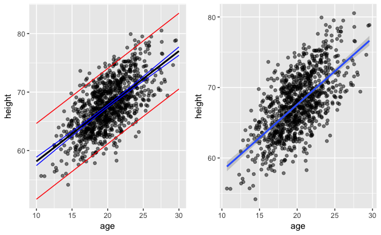

```r
g1 <- ggplot(data = d, aes(x = age, y = height))
g1 <- g1 + geom_point(alpha = 1/2)
g1 <- g1 + geom_line(data = df, aes(x = v, y = CIfit), colour = "black", lwd = 1)
g1 <- g1 + geom_line(data = df, aes(x = v, y = CIlwr), colour = "blue")
g1 <- g1 + geom_line(data = df, aes(x = v, y = CIupr), colour = "blue")
g1 <- g1 + geom_line(data = df, aes(x = v, y = PIlwr), colour = "red")
g1 <- g1 + geom_line(data = df, aes(x = v, y = PIupr), colour = "red")
g2 <- ggplot(data = d, aes(x = age, y = height))
g2 <- g2 + geom_point(alpha = 1/2)
g2 <- g2 + geom_smooth(method = "lm", formula = y ~ x)
grid.arrange(g1, g2, ncol = 2)
```

Again, here the CI band shows where the mean height is expected to fall in 95% of samples and the PI band shows where the individual points are expected to fall 95% of the time.

## Residuals

If there is structure in residuals - it means there is a variable that needs to be measured becuase its having an effect on the variables you have measured.